# Flavors of Cacao Analysis

Kwazikwakhe Nkosi

09/07/2026

# Install packages

```r
# Install packages
packages <- c(
  "tidyverse",
  "janitor",
  "skimr",
  "corrplot",
  "GGally",
  "caret",
  "randomForest",
  "DataExplorer"
)
installed <- packages %in% installed.packages()

if(any(!installed))
  install.packages(packages[!installed])
install.packages("naniar")
```

# Load Package

```r
library(tidyverse)
library(janitor)
library(skimr)
library(corrplot)
library(GGally)
library(caret)
library(randomForest)
library(DataExplorer)
library(dplyr)
library(stringr)
library(naniar)
```

# Import Dataset

```r
# Import Dataset
df_cacoa1 <- read_csv(
  "flavors_of_cacao.csv",
  locale = locale(encoding = "Latin1")
)
```

# Clean Column Names

```r
df_cacoa <- df_cacoa1 %>%
    clean_names()

names(df_cacoa)
```

```
## [1] "company_a_maker_if_known"         "specific_bean_origin_or_bar_name"
## [3] "ref"                              "review_date"
## [5] "cocoa_percent"                    "company_location"
## [7] "rating"                           "bean_type"
## [9] "broad_bean_origin"
```

## Rename some variables

```r
df_cacoa <- df_cacoa |>
  rename(
    company = company_a_maker_if_known,
    specific_origin = specific_bean_origin_or_bar_name,
    review_year = review_date,
    broad_origin = broad_bean_origin
  )
```

## Clean text columns

```r
df_cacoa$cocoa_percent <- as.numeric(str_remove(df_cacoa$cocoa_percent, "%"))

#function to clean text columns
clean_text <- function(x){

  #remove non breaking spaces
  x <- stringr::str_replace_all(x, "\u00A0", "")

  #remove all non ASCII characters
  x <- iconv(x, from= "UTF-8", to = "ASCII", sub = "")

  #trim white space
  x[x=="" | is.na(x)] <- "unknown"

  return(x)
}

#apply to all character columns
df_cacoa <- df_cacoa %>%
  mutate(
    across(
      c(company,specific_origin,
        company_location,
        bean_type,
        broad_origin),
      clean_text)
    )

#convert to numeric
df_cacoa <- df_cacoa %>%
  mutate(
    cocoa_percent = as.numeric(cocoa_percent),
    rating = as.numeric(rating)
  )
# Data quality checks
print(colSums(is.na(df_cacoa)))
```

```
##          company  specific_origin              ref      review_year
##                0                0                0                0
##    cocoa_percent company_location           rating        bean_type
##                0                0                0                0
##     broad_origin
##                0
```

```r
print(sum(duplicated(df_cacoa)))
```

```
## [1] 0
```

```r
summary(df_cacoa)
```

```
##       company      specific_origin      ref        review_year
##  Length   :1795   Length   :1795   Min.   :   5   Min.   :2006
##  N.unique : 416   N.unique :1039   1st Qu.: 576   1st Qu.:2010
##  N.blank  :   0   N.blank  :   0   Median :1069   Median :2013
##  Min.nchar:   2   Min.nchar:   3   Mean   :1036   Mean   :2012
##  Max.nchar:  39   Max.nchar:  45   3rd Qu.:1502   3rd Qu.:2015
##                                    Max.   :1952   Max.   :2017
##  cocoa_percent    company_location     rating          bean_type
##  Min.   : 42.0   Length   :1795    Min.   :1.000   Length   :1795
##  1st Qu.: 70.0   N.unique :  60    1st Qu.:2.875   N.unique :  41
##  Median : 70.0   N.blank  :   0    Median :3.250   N.blank  :   0
##  Mean   : 71.7   Min.nchar:   4    Mean   :3.186   Min.nchar:   3
##  3rd Qu.: 75.0   Max.nchar:  17    3rd Qu.:3.500   Max.nchar:  24
##  Max.   :100.0                     Max.   :5.000
##     broad_origin
##  Length   :1795
##  N.unique : 100
##  N.blank  :   0
##  Min.nchar:   4
##  Max.nchar:  29
##
```

# Distribution of Cocoa Percentage

[figure not shown]

```r
# Outliers
# Distribution of Cocoa Percentage

ggplot(df_cacoa, aes(x = cocoa_percent)) +
  geom_histogram(
    aes(y = after_stat(density)),
    binwidth = 0.05,
    fill = "#8B4513",      # Chocolate brown
    colour = "white",
    linewidth = 0.4,
    alpha = 0.85
  ) +
  geom_density(
    colour = "#2E4057",    # Dark blue
    linewidth = 1.3
  ) +
  scale_x_continuous(
    labels = scales::percent_format(accuracy = 1),
    breaks = seq(0.4, 1.0, by = 0.1)
  ) +
  labs(
    title = "Distribution of Cacao Percentage",
    subtitle = "Distribution of cacao content across all reviewed chocolate bars",
    x = "Cacao Percentage",
    y = "Density"
  ) +
  theme_minimal(base_size = 13) +
  theme(
    plot.title = element_text(face = "bold", hjust = 0.5, size = 16),
    plot.subtitle = element_text(hjust = 0.5, colour = "grey40"),
    axis.title = element_text(face = "bold"),
    axis.text = element_text(colour = "black"),
    panel.grid.minor = element_blank(),
    panel.grid.major.x = element_line(colour = "grey85"),
    panel.grid.major.y = element_line(colour = "grey90")
  )
```

## Description

This histogram illustrates the frequency distribution of cocoa percentages among all reviewed chocolate bars.

## Technical Interpretation

The cocoa percentages are heavily concentrated between 60% and 75%, with approximately 70% cocoa representing the most common formulation. Chocolates containing extremely low or extremely high cocoa percentages occur much less frequently.

## Business Interpretation

Manufacturers tend to formulate products within the cocoa range most preferred by consumers. This concentration suggests that balancing bitterness and sweetness around 70% cocoa provides the greatest commercial appeal.

## Key Insight

Most premium chocolates are produced with cocoa percentages between 60% and 75%.

# Rating Distribution

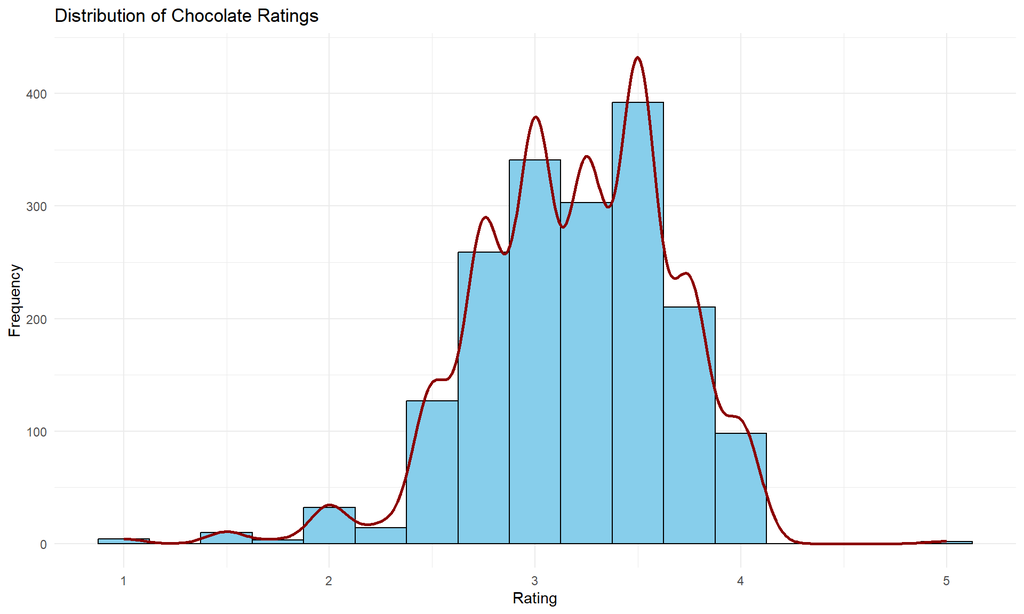

```r
# Rating Distribution
ggplot(df_cacoa, aes(x = rating)) +
  geom_histogram(binwidth = 0.25,
                 fill = "skyblue",
                 colour = "black") +
  geom_density(aes(y = after_stat(count * 0.25)),
               colour = "darkred",
               linewidth = 1) +
  labs(
    title = "Distribution of Chocolate Ratings",
    x = "Rating",
    y = "Frequency"
  ) +
  theme_minimal()
```

The near-normal distribution of ratings suggests that the chocolate review process is balanced and does not disproportionately favour either very high or very low ratings. This provides confidence that the dataset offers a representative assessment of premium chocolate products. From a business perspective, the findings imply that manufacturers generally meet consumer expectations, but only a small proportion successfully exceed them. Companies aiming to strengthen their market position should focus on continuous product improvement and innovation to achieve ratings above 4.0, where products are more likely to be recognised as premium or award-winning.

# Missingness

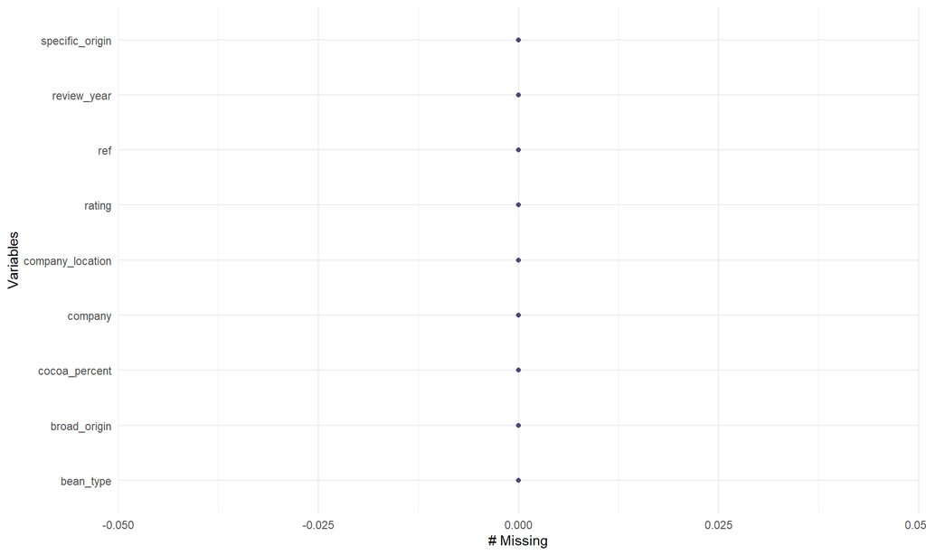

```r
# Missingness
gg_miss_var(df_cacoa)
```

# Correlation plot

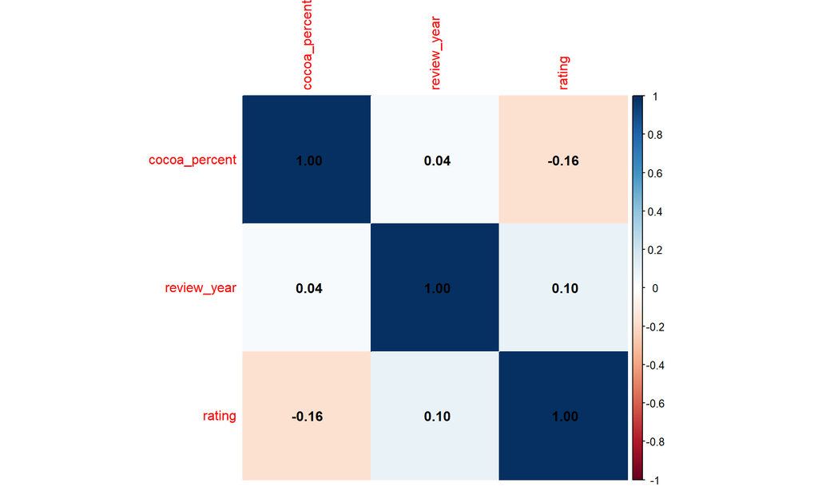

```r
# Correlation
num <- df_cacoa|>select(cocoa_percent,review_year,rating)
corrplot(cor(num),method="color",addCoef.col="black")
```

# Feature Engineering

```r
# Feature Engineering
df_cacoa <- df_cacoa |>
  mutate(
    cocoa_group=case_when(
      cocoa_percent<0.60~"Low",
      cocoa_percent<0.75~"Medium",
      cocoa_percent<0.85~"High",
      TRUE~"Very High"
    ),
    Elite=ifelse(rating>=3.75,1,0)
  )

# Create Rating Groups
df_cacoa <- df_cacoa %>%
  mutate(
    rating_group = case_when(
      rating < 2.5 ~ "Low",
      rating < 4.0 ~ "Medium",
      TRUE ~ "High"
    )
  )

# Create Cocoa Percentage Groups
# Create Cocoa Percentage Groups
df_cacoa <- df_cacoa %>%
  mutate(
    cocoa_group = case_when(
      cocoa_percent >= 40 & cocoa_percent <= 59 ~ "Low",
      cocoa_percent >= 60 & cocoa_percent <= 74 ~ "Medium",
      cocoa_percent >= 75 & cocoa_percent <= 89 ~ "High",
      cocoa_percent >= 90 & cocoa_percent <= 100 ~ "Very High",
      TRUE ~ NA_character_
    )
  )
```

# Scatter Plot

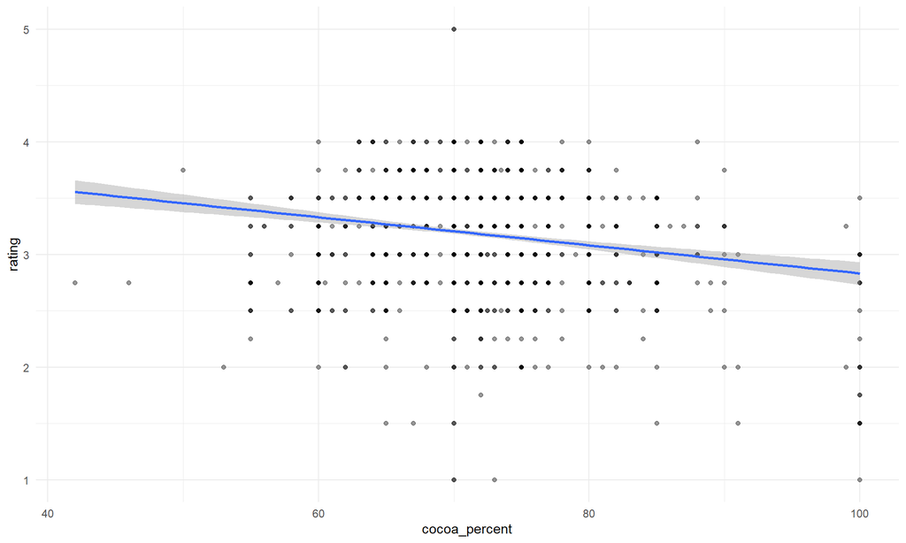

```r
# Scatter
ggplot(df_cacoa,aes(cocoa_percent,rating))+
  geom_point(alpha=.4)+
  geom_smooth(method="lm")+
  theme_minimal()
```

## Description

This scatter plot examines the relationship between cocoa percentage and chocolate rating.

## Business Interpretation

Simply increasing cocoa percentage does not improve consumer ratings. Manufacturers should instead focus on ingredient quality, processing methods, flavour balance, and overall sensory experience.

## Key Insight

Higher cocoa content alone does not guarantee higher-quality chocolate.

# Histogram of Chocolate Ratings

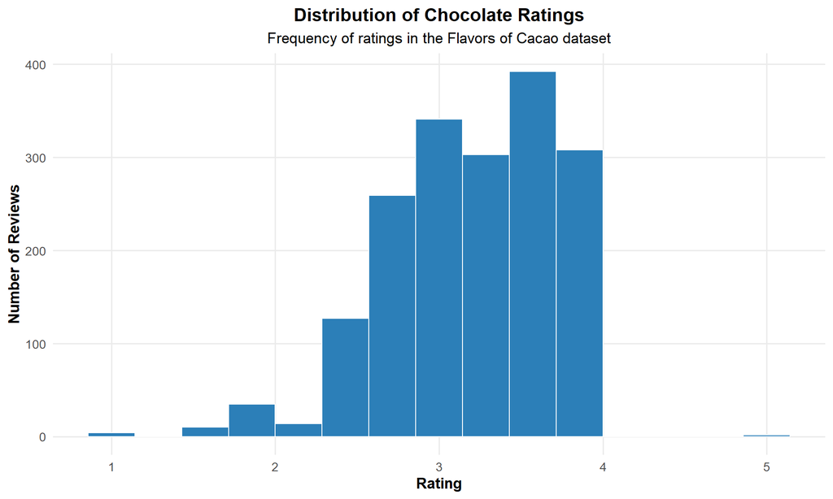

```r
# Histograms
# Histogram of Chocolate Ratings

ggplot(df_cacoa, aes(x = rating)) +
  geom_histogram(
    bins = 15,
    fill = "#2C7FB8",      # Professional blue
    colour = "white",
    linewidth = 0.4
  ) +
  labs(
    title = "Distribution of Chocolate Ratings",
    subtitle = "Frequency of ratings in the Flavors of Cacao dataset",
    x = "Rating",
    y = "Number of Reviews"
  ) +
  theme_minimal(base_size = 13) +
  theme(
    plot.title = element_text(face = "bold", hjust = 0.5),
    plot.subtitle = element_text(hjust = 0.5),
    axis.title = element_text(face = "bold"),
    panel.grid.minor = element_blank()
  )
```

The distribution demonstrates that reviewers consistently rate most chocolate products positively, reflecting the overall maturity and quality of the premium chocolate market. Since the ratings cluster within a narrow range, manufacturers face strong competition, where even small improvements in flavour, texture, aroma, and bean sourcing can significantly influence consumer perception and product differentiation. Therefore, organisations aiming to strengthen their competitive position should prioritise continuous quality improvement and innovation rather than relying solely on increasing cocoa content or expanding product offerings.

# Distribution of Cocoa Percentage

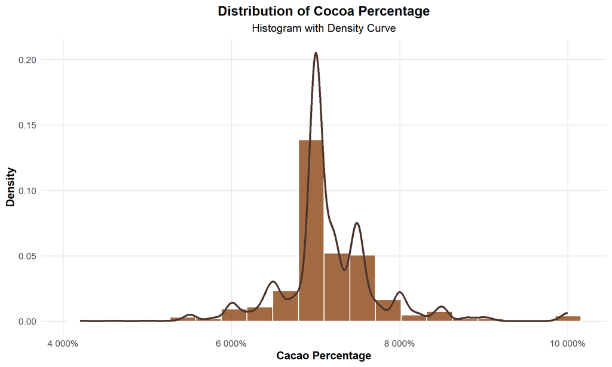

```r
ggplot(df_cacoa, aes(x = cocoa_percent)) +
  geom_histogram(
    aes(y = after_stat(density)),
    bins = 20,
    fill = "#8B4513",
    colour = "white",
    alpha = 0.8
  ) +
  geom_density(
    colour = "#4E342E",
    linewidth = 1.2
  ) +
  scale_x_continuous(labels = scales::percent_format(accuracy = 1)) +
  labs(
    title = "Distribution of Cocoa Percentage",
    subtitle = "Histogram with Density Curve",
    x = "Cacao Percentage",
    y = "Density"
  ) +
  theme_minimal(base_size = 13) +
  theme(
    plot.title = element_text(face = "bold", hjust = 0.5),
    plot.subtitle = element_text(hjust = 0.5),
    axis.title = element_text(face = "bold"),
    panel.grid.minor = element_blank()
  )
```

# Distribution of Ratings

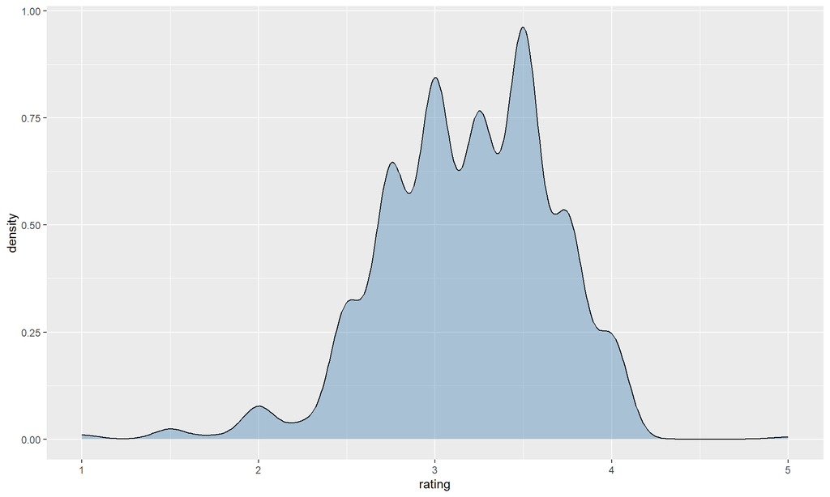

```r
ggplot(df_cacoa,aes(rating))+geom_density(fill="steelblue",alpha=.4)
```

# Distribution of Chocolate Ratings by Rating Group

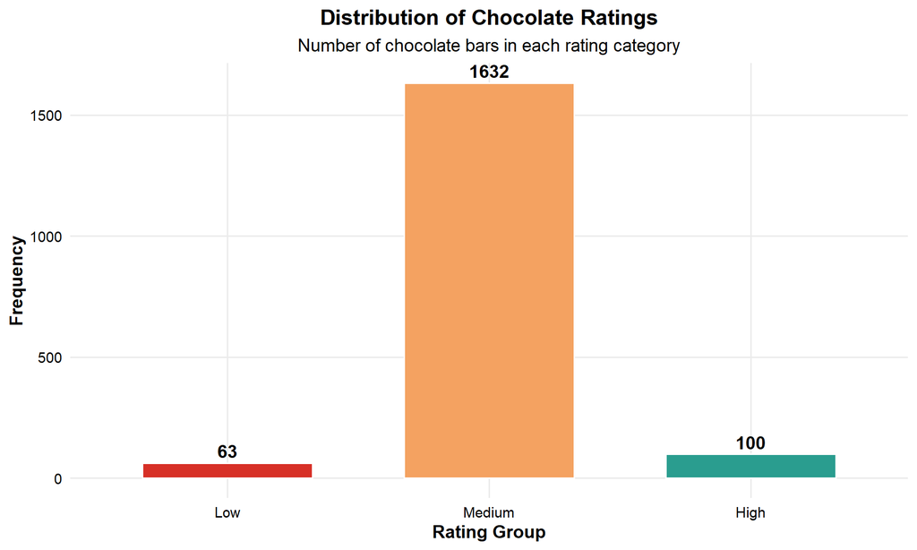

```r
#Summarise the Groups
rating_summary <- df_cacoa %>%
  group_by(rating_group) %>%
  summarise(
    Count = n(),
    .groups = "drop"
  )


# Distribution of Chocolate Ratings by Rating Group

rating_summary$rating_group <- factor(
  rating_summary$rating_group,
  levels = c("Low", "Medium", "High")
)

ggplot(rating_summary,
       aes(x = rating_group,
           y = Count,
           fill = rating_group)) +
  geom_col(width = 0.65, colour = "white") +
  geom_text(aes(label = Count),
            vjust = -0.4,
            size = 5,
            fontface = "bold") +
  scale_fill_manual(values = c(
    "Low" = "#D73027",
    "Medium" = "#F4A261",
    "High" = "#2A9D8F"
  )) +
  labs(
    title = "Distribution of Chocolate Ratings",
    subtitle = "Number of chocolate bars in each rating category",
    x = "Rating Group",
    y = "Frequency"
  ) +
  theme_minimal(base_size = 14) +
  theme(
    plot.title = element_text(face = "bold", hjust = 0.5),
    plot.subtitle = element_text(hjust = 0.5),
    axis.title = element_text(face = "bold"),
    axis.text = element_text(colour = "black"),
    legend.position = "none",
    panel.grid.minor = element_blank()
  )
```

The distribution of rating groups reinforces earlier findings from the histogram and density plot, which showed that chocolate ratings cluster around the middle of the rating scale. This consistency suggests that the premium chocolate industry maintains a relatively high standard of quality, with few products receiving extremely poor or exceptional ratings.

The overwhelming concentration in the Medium category also indicates that manufacturers operate in a highly competitive market where most products offer similar levels of quality. Consequently, companies aiming to gain a competitive advantage should focus on innovations in flavour development, premium bean sourcing, sustainable production practices, and overall consumer experience to move products from the medium category into the high-performing segment.

# Country summaries

```r
# Country summaries
country_summary <- df_cacoa |>
  group_by(company_location) |>
  summarise(Reviews=n(),Average_Rating=mean(rating),.groups="drop")
```

# Top 10 Countries by Average Chocolate Rating

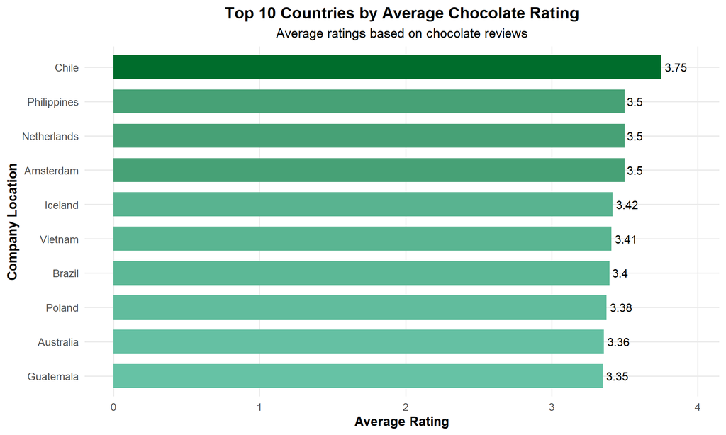

```r
# Top 10 Countries by Average Chocolate Rating

top_countries <- country_summary %>%
  arrange(desc(Average_Rating)) %>%
  slice_head(n = 10)

ggplot(top_countries,
       aes(x = reorder(company_location, Average_Rating),
           y = Average_Rating,
           fill = Average_Rating)) +
  geom_col(width = 0.7) +
  geom_text(aes(label = round(Average_Rating, 2)),
            hjust = -0.15,
            size = 4) +
  coord_flip() +
  scale_fill_gradient(
    low = "#66C2A5",
    high = "#006D2C"
  ) +
  labs(
    title = "Top 10 Countries by Average Chocolate Rating",
    subtitle = "Average ratings based on chocolate reviews",
    x = "Company Location",
    y = "Average Rating"
  ) +
  theme_minimal(base_size = 13) +
  theme(
    plot.title = element_text(face = "bold", hjust = 0.5),
    plot.subtitle = element_text(hjust = 0.5),
    axis.title = element_text(face = "bold"),
    legend.position = "none",
    panel.grid.minor = element_blank()
  ) +
  expand_limits(y = max(top_countries$Average_Rating) + 0.2)
```

The analysis indicates that differences in average chocolate ratings among the leading countries are relatively small, suggesting that the premium chocolate industry maintains high standards worldwide. Rather than one country dominating the market, several countries consistently produce products that receive favourable consumer evaluations.

These findings imply that competitive advantage is determined less by geographic location and more by factors such as high-quality cocoa sourcing, manufacturing expertise, flavour innovation, sustainability practices, and quality assurance. Consequently, chocolate manufacturers should focus on continuous product improvement and differentiation to enhance customer satisfaction and strengthen their position within the global premium chocolate market.

# Top 10 Countries by Number of Reviews

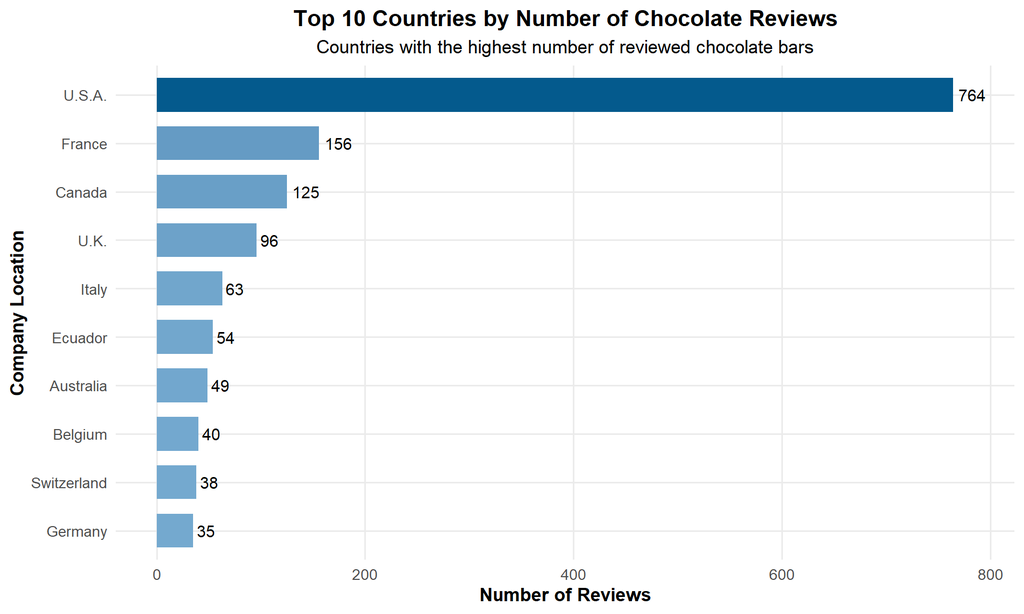

```r
# Top 10 Countries by Number of Reviews

top_reviews <- country_summary %>%
  arrange(desc(Reviews)) %>%
  slice_head(n = 10)

ggplot(top_reviews,
       aes(x = reorder(company_location, Reviews),
           y = Reviews,
           fill = Reviews)) +
  geom_col(width = 0.7) +
  geom_text(aes(label = Reviews),
            hjust = -0.2,
            size = 4) +
  coord_flip() +
  scale_fill_gradient(
    low = "#74A9CF",
    high = "#045A8D"
  ) +
  labs(
    title = "Top 10 Countries by Number of Chocolate Reviews",
    subtitle = "Countries with the highest number of reviewed chocolate bars",
    x = "Company Location",
    y = "Number of Reviews"
  ) +
  theme_minimal(base_size = 13) +
  theme(
    plot.title = element_text(face = "bold", hjust = 0.5),
    plot.subtitle = element_text(hjust = 0.5),
    axis.title = element_text(face = "bold"),
    legend.position = "none",
    panel.grid.minor = element_blank()
  ) +
  expand_limits(y = max(top_reviews$Reviews) + 20)
```

# Average Rating Trend by Review Year

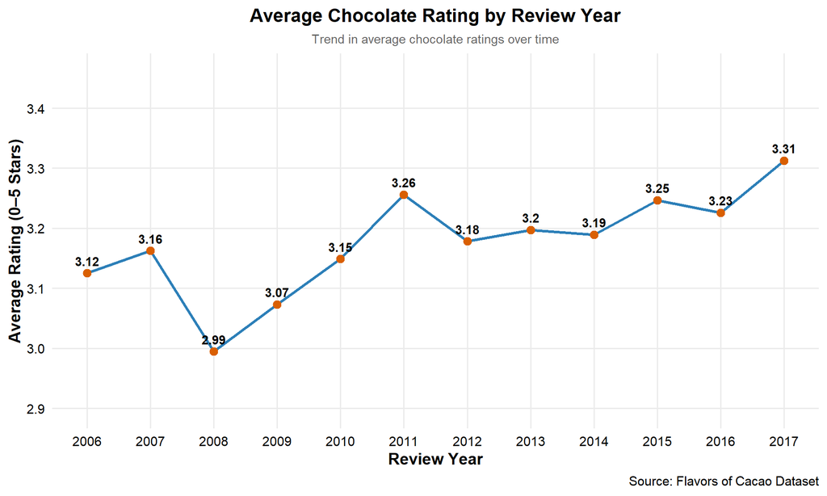

```r
# Trends
# Average Rating Trend by Review Year

yr <- df_cacoa %>%
  group_by(review_year) %>%
  summarise(
    Average_Rating = mean(rating),
    Reviews = n(),
    .groups = "drop"
  )

ggplot(yr, aes(x = review_year, y = Average_Rating)) +
  geom_line(
    colour = "#2C7FB8",
    linewidth = 1.2
  ) +
  geom_point(
    colour = "#D95F02",
    size = 3
  ) +
  geom_text(
    aes(label = round(Average_Rating, 2)),
    vjust = -0.8,
    size = 3.8,
    fontface = "bold"
  ) +
  scale_x_continuous(breaks = yr$review_year) +
  scale_y_continuous(
    limits = c(min(yr$Average_Rating) - 0.1,
               max(yr$Average_Rating) + 0.15)
  ) +
  labs(
    title = "Average Chocolate Rating by Review Year",
    subtitle = "Trend in average chocolate ratings over time",
    x = "Review Year",
    y = "Average Rating (0–5 Stars)",
    caption = "Source: Flavors of Cacao Dataset"
  ) +
  theme_minimal(base_size = 14) +
  theme(
    plot.title = element_text(face = "bold", size = 16, hjust = 0.5),
    plot.subtitle = element_text(size = 11, hjust = 0.5, colour = "grey40"),
    axis.title = element_text(face = "bold"),
    axis.text = element_text(colour = "black"),
    panel.grid.minor = element_blank()
  )
```

# Cocoa Distribution

[figure not shown]

```r
# Cocoa Distribution

# Distribution of Cocoa Percentage

ggplot(df_cacoa, aes(x = cocoa_percent)) +
  geom_histogram(
    bins = 20,
    fill = "#8B4513",       # Chocolate brown
    colour = "white",
    linewidth = 0.5
  ) +
  scale_x_continuous(
    labels = scales::percent_format(accuracy = 1),
    breaks = seq(0.4, 1.0, by = 0.1)
  ) +
  labs(
    title = "Distribution of Cacao Percentage",
    subtitle = "Frequency of cacao content across reviewed chocolate",
    x = "Cacao Percentage",
    y = "Frequency",
    caption = "Source: Flavors of Cacao Dataset"
  ) +
  theme_minimal(base_size = 14) +
  theme(
    plot.title = element_text(
      face = "bold",
      size = 16,
      hjust = 0.5
    ),
    plot.subtitle = element_text(
      size = 11,
      colour = "grey40",
      hjust = 0.5
    ),
    axis.title = element_text(face = "bold"),
    axis.text = element_text(colour = "black"),
    panel.grid.minor = element_blank()
  )
```

# Top 15 Chocolate Companies by Number of Reviews

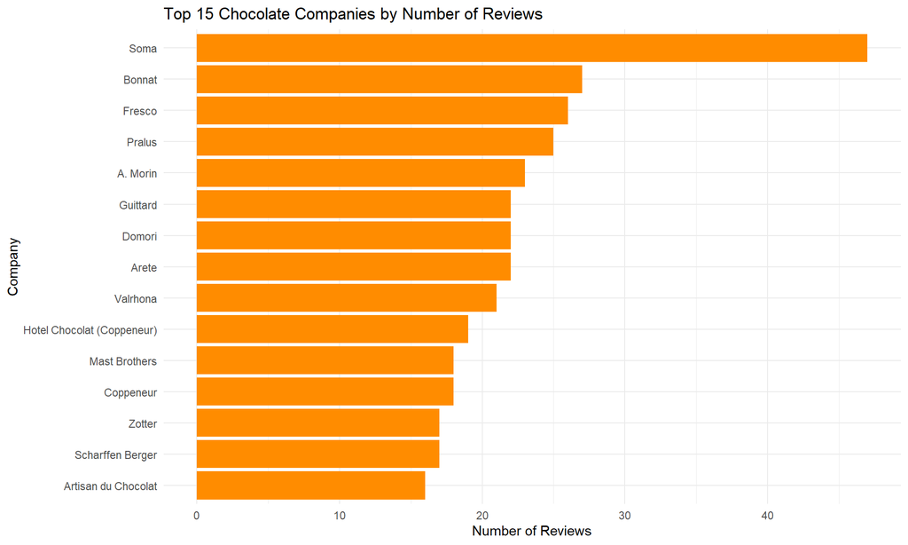

```r
company_reviews <- df_cacoa %>%
  count(company, sort = TRUE) %>%
  slice(1:15)

ggplot(company_reviews,
       aes(reorder(company, n), n)) +
  geom_col(fill = "darkorange") +
  coord_flip() +
  labs(
    title = "Top 15 Chocolate Companies by Number of Reviews",
    x = "Company",
    y = "Number of Reviews"
  ) +
  theme_minimal()
```